# HW4

Kevin Neal

May 8, 2015

## Part I: Further Reading

### Metaanalysis (Nakagawa and Cuthill, 2007)

Summary: The article identifies the need for common use of effect size in biological sciences, noting that NHST alone says nothing about the magnitude of an effect of interest or the precision of that estimate. The authors identify three whays in which NHST can mislead: 1) null hypotheses cannot be true for populations in the real world, except with categorical data; 2) NHST gives undue importance to just one of any number of hypotheses that could be tested; 3) NHST-centric research encourages dismissal rather than probabilistic or likelihood-based assessment of results. The authors note meta-analysis as being an effect-size-based review of research that “naturally thinks outside the limits of NHST.”

How metaanalysis works: Meta-analysis works by combining results from different studies within the same area of research by estimating central tendency and variability of effect sizes across included studies. It necessitates a comparison of effect sizes and confidence intervals, rather than simply looking at p-values.  
Comments on remarks about multiple regression: The authors note that the predictors included in a multiple regression model will determine the effect size, given that there will be some covariance, and thus it is important to make an informed decision on which predictors to include in the model. The authors identify three approaches usually taken for model selection: the backwards elimination method (based on Occam’s razor); Akaike Information Criterion; and a Bayesian approach.

### Multicollinearity (Slinker and Glantz, 1985)

Explain multicollinearity and describe some ways to detect and deal with it Multicollinearity is the correlation of two or more predictor variables in a model for a response variable. One can think of multiple regression as trying to find a plane, hyperplane etc. analogous to a regression line, but in multiple dimensions. In a case with two uncorrelated predictors, both provide information to help place the regression plane. In a case with two correlated predictors, one is basically fitting a plane to a line, so the plane could intersect all the predictor points while being able to rotate freely around it (i.e. a number of different models/planes limit the residuals equally well)–thus one loses information for determining parameters in the regression model.

One can detect multicollinearity first by evaluating the model parameters relative to expectations. Model parameters conflicting with theoretical knowledge of the magnitude of a predictor can also point to multicollinearity. Unexpected direction of the response to the predictor variable may also be an indicator of multicollinearity. Beyond investigating violations of expectations, correlation values greater than 0.7-0.8 generally signify multicollinearity between two variables as well. One may also compute the variance inflation factor or examine eigenvectors and eigenvalues in a correlation matrix of all the standardized predictors.

To deal with multicollinearity, one may collect more data; remove one of a pair of highly correlated predictors; substitude a predictor for a transformed or rescaled predictor; or follow any of a number of biased regression procedures when it is not possible to collect more data or remove/substitute predictors.

# Part II: Data Analysis

## Multiple Regression Tutorial

```r
# using built-in state.x77 dataset
st <- as.data.frame(state.x77)
colnames(st)[4] <- "Life.Exp" # getting rid of spaces in column names
colnames(st)[6] <- "HS.Grad"
st[,9] <- st$Population*1000 / st$Area # creates new column with these values
colnames(st)[9] <- "Density" # renames the column I just made

summary(st)
```

```
##    Population        Income       Illiteracy       Life.Exp
##  Min.   :  365   Min.   :3098   Min.   :0.500   Min.   :67.96
##  1st Qu.: 1080   1st Qu.:3993   1st Qu.:0.625   1st Qu.:70.12
##  Median : 2838   Median :4519   Median :0.950   Median :70.67
##  Mean   : 4246   Mean   :4436   Mean   :1.170   Mean   :70.88
##  3rd Qu.: 4968   3rd Qu.:4814   3rd Qu.:1.575   3rd Qu.:71.89
##  Max.   :21198   Max.   :6315   Max.   :2.800   Max.   :73.60
##      Murder          HS.Grad          Frost             Area
##  Min.   : 1.400   Min.   :37.80   Min.   :  0.00   Min.   :  1049
##  1st Qu.: 4.350   1st Qu.:48.05   1st Qu.: 66.25   1st Qu.: 36985
##  Median : 6.850   Median :53.25   Median :114.50   Median : 54277
##  Mean   : 7.378   Mean   :53.11   Mean   :104.46   Mean   : 70736
##  3rd Qu.:10.675   3rd Qu.:59.15   3rd Qu.:139.75   3rd Qu.: 81163
##  Max.   :15.100   Max.   :67.30   Max.   :188.00   Max.   :566432
##     Density
##  Min.   :  0.6444
##  1st Qu.: 25.3352
##  Median : 73.0154
##  Mean   :149.2245
##  3rd Qu.:144.2828
##  Max.   :975.0033
```

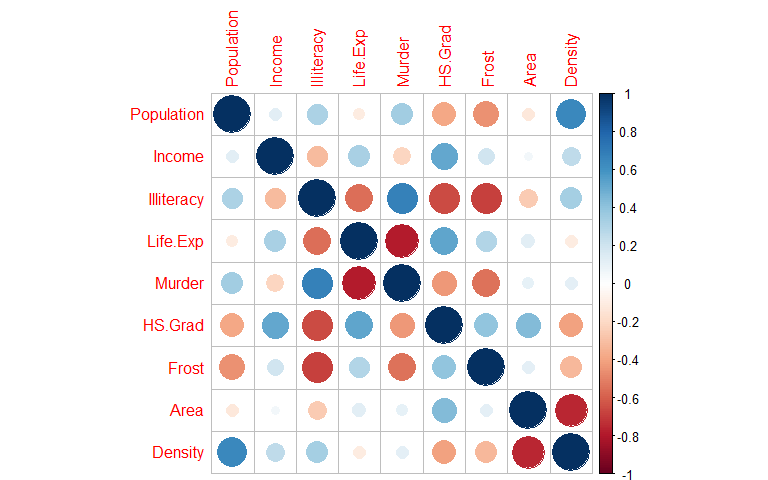

```r
corrplot(cor(st, method="spearman"))
```

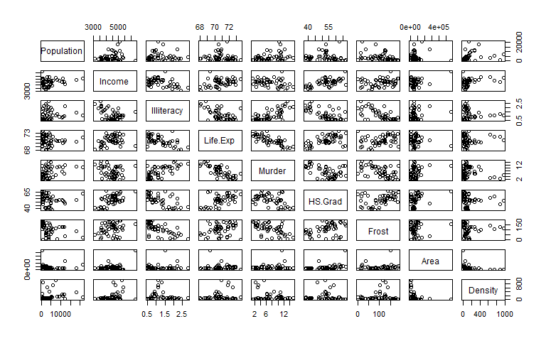

```r
pairs(st)
```

### Modeling

```r
options(show.signif.stars = T) # cuz why not
names(st)
```

```
## [1] "Population" "Income"     "Illiteracy" "Life.Exp"   "Murder"
## [6] "HS.Grad"    "Frost"      "Area"       "Density"
```

```r
model1 <- lm(Life.Exp ~ Population + Income + Illiteracy + Murder + HS.Grad + Frost + Area + Density, data=st)
summary(model1) # murder and population significant; area and illiteracy worst predictors. Tutorial removes area...
```

```
##
## Call:
## lm(formula = Life.Exp ~ Population + Income + Illiteracy + Murder +
##     HS.Grad + Frost + Area + Density, data = st)
##
## Residuals:
##      Min       1Q   Median       3Q      Max
## -1.47514 -0.45887 -0.06352  0.59362  1.21823
##
## Coefficients:
##               Estimate Std. Error t value Pr(>|t|)
## (Intercept)  6.995e+01  1.843e+00  37.956  < 2e-16 ***
## Population   6.480e-05  3.001e-05   2.159   0.0367 *
## Income       2.701e-04  3.087e-04   0.875   0.3867
## Illiteracy   3.029e-01  4.024e-01   0.753   0.4559
## Murder      -3.286e-01  4.941e-02  -6.652 5.12e-08 ***
## HS.Grad      4.291e-02  2.332e-02   1.840   0.0730 .
## Frost       -4.580e-03  3.189e-03  -1.436   0.1585
## Area        -1.558e-06  1.914e-06  -0.814   0.4205
## Density     -1.105e-03  7.312e-04  -1.511   0.1385
## ---
## Signif. codes:  0 '***' 0.001 '**' 0.01 '*' 0.05 '.' 0.1 ' ' 1
##
## Residual standard error: 0.7337 on 41 degrees of freedom
## Multiple R-squared:  0.7501, Adjusted R-squared:  0.7013
## F-statistic: 15.38 on 8 and 41 DF,  p-value: 3.787e-10
```